# Subgroup utility heterogeneity in decision curve analysis with voipred.dev

November 4, 2026

This guide shows how voipred.dev implements the framework of Wang, Wang, Van Calster, van Geloven, Steyerberg and Wynants, *Population-level decision curve analysis may mislead the evaluation of prediction model usefulness under subgroup utility heterogeneity*. It is meant for collaborators: it reproduces the two examples of the paper, applies the framework to the GUSTO-I data, and goes through the options. Only the methods of the paper are implemented.

# 1 Installation

**Installation and updates are automatic.** When the guide is knitted, its first chunk installs the packages it uses that are missing or too old, and installs voipred.dev from GitHub, or updates it when GitHub has a newer version. If you run the chunks one by one instead, restart R first (Session > Restart R), so that voipred.dev can be updated.

```r
# Installs what is missing, and voipred.dev (or its newer version) from GitHub,
# before anything is loaded. Nothing is done during R CMD check.
if (!nzchar(Sys.getenv("_R_CHECK_PACKAGE_NAME_"))) {
  if (is.null(getOption("repos")[["CRAN"]]) || getOption("repos")[["CRAN"]] == "@CRAN@")
    options(repos = c(CRAN = "https://cloud.r-project.org"))
  options(install.packages.compile.from.source = "never")
  lib <- Sys.getenv("R_LIBS_USER")
  dir.create(lib, recursive = TRUE, showWarnings = FALSE)
  .libPaths(c(lib, .libPaths()))
  # packages this guide uses, with minimum versions; checked without loading them
  pkgs <- c(remotes = "0", insight = "0", Rcpp = "0", ggplot2 = "3.4.0",
            riskRegression = "2026.3.11")
  installed <- function(p) nzchar(system.file(package = p))
  old <- function(p) !installed(p) || utils::packageVersion(p) < pkgs[[p]]
  new <- names(pkgs)[vapply(names(pkgs), old, logical(1))]
  if (length(new)) install.packages(new, lib = lib)
  # voipred.dev: installed, or updated when GitHub has a newer version
  if ("voipred.dev" %in% loadedNamespaces()) {
    message("voipred.dev is already loaded in this R session, so it is not updated: ",
            "knit the guide, or restart R (Session > Restart R) first.")
  } else {
    tryCatch(remotes::install_github("amirfarahmand0/voipred_dev", upgrade = "never",
                                     lib = lib),
             error = function(e) message("voipred.dev could not be updated (",
                                         conditionMessage(e), "); the installed version is used."))
  }
  sha <- utils::packageDescription("voipred.dev")$RemoteSha
  cat("voipred.dev", format(utils::packageVersion("voipred.dev")),
      if (!is.null(sha)) paste("- GitHub commit", substr(sha, 1, 7)), "\n")
}
```

```
#> -- R CMD build -----------------------------------------------------------------
#> * checking for file '/tmp/Rtmpq89Ol5/remotes2fc428f87f/amirfarahmand0-voipred_dev-1b6266f/DESCRIPTION' ... OK
#> * preparing 'voipred.dev':
#> * checking DESCRIPTION meta-information ... OK
#> * cleaning src
#> * checking for LF line-endings in source and make files and shell scripts
#> * checking for empty or unneeded directories
#> * building 'voipred.dev_0.0.2.9000.tar.gz'
#>
#> voipred.dev 0.0.2.9000 - GitHub commit 1b6266f
```

```r
library(voipred.dev)
library(survival)
```

# 2 The idea

Net benefit is expressed in units of $a - c$, the incremental utility of a true positive relative to a false negative (written $k$). Within a homogeneous population, the difference in utility between two strategies is $\Delta U = k \, \Delta NB$, so net benefit and utility always favour the same strategy. With subgroups $i = 1, \dots, m$ of sizes $n_i$, the population difference in net benefit is the size-weighted sum of the subgroup differences, whereas the population difference in utility also weights each subgroup by its $k_i$:
$$\Delta NB \propto \sum_i n_i \, \Delta NB_i,
\qquad
\Delta U \propto \sum_i n_i \, k_i \, \Delta NB_i .$$
When the $k_i$ differ, the two can have opposite signs: population net benefit then favours one strategy and population utility the other. This is possible only when the subgroup $\Delta NB_i$ do not all have the same sign. For two subgroups, the combinations $(\Delta NB_1, \Delta NB_2)$ for which this happens form the **inconsistency region**, between the lines $y = -(n_1/n_2)\,x$ and $y = -(n_1 k_1)/(n_2 k_2)\,x$, and the **K-value**
$$K = -\frac{n_2 \,
\Delta NB_2}{n_1 \, \Delta NB_1}$$
is the critical ratio $k_1/k_2$: when $k_1 > k_2$, population net benefit and utility favour different strategies if $k_1/k_2 > K$ (and if $k_1/k_2 < K$ when $k_1 < k_2$).

**Notation.** In the paper, $\Delta NB_i$ is the difference in net benefit between the model and a comparator that is the **same strategy in every subgroup** (e.g. treat all), so that the sums above compare two population strategies. voipred.dev calls it **`diff_NB`** (columns `diff_NB_<subgroup>`, and `diff_NB_population` for the share-weighted sum), to keep it apart from **`delta_NB`**, which in `nb_val()` compares the model with the best default strategy of each group, $\max(NB_{all}, NB_{none})$, chosen separately in each subgroup. The two coincide only when the best default strategy is the comparator in every subgroup. The utility-weighted difference $\sum_i n_i k_i \Delta NB_i$ is **`diff_utility`**.

**The framework of the paper, and where it is in voipred.dev:**

| Step | In the paper | In voipred.dev |
| --- | --- | --- |
| 1 | Decision curve analysis within subgroups | `nb_val(..., subgroup = )` |
| 2 | Do the subgroup $\Delta NB_i$ have the same sign? If so, differences in $k$ cannot change the population conclusion | `summary(res)`: columns `diff_NB_<subgroup>` and `signs` |
| 3 | If not: is $(\Delta NB_1, \Delta NB_2)$ in the inconsistency region (with external evidence on $k$, e.g. the relative risk reductions of the treatment for a prognostic model), or what is the K-value? … | `summary(res, k = )`: columns `K`, `diff_utility` and `consistent`; `plot(res, type = "region")` |
|  | The K-value from published results | `k_value()` |

# 3 The motivating example of the paper

Two subgroups of equal size, each with a prevalence of 50%, at a threshold of 0.0625 (Tables 1 and 2 of the paper; here 100 patients per subgroup, which gives the same proportions). The model has a specificity of 98% in both and a sensitivity of 90% in group 1 and 98% in group 2. The utilities give $a_1 - c_1 = 60$ and $a_2 - c_2 = 45$.

```r
make_group <- function(tp, fp, fn, tn, group)
  data.frame(y = c(rep(1, tp), rep(0, fp), rep(1, fn), rep(0, tn)),
             p = c(rep(0.9, tp + fp), rep(0.01, fn + tn)),
             group = group)
d <- rbind(make_group(45, 1, 5, 49, "Group 1"),
           make_group(49, 1, 1, 49, "Group 2"))
res_m <- nb_val(data = d,
                predicted_risk = "p",
                outcome = "y",
                thresholds = 0.0625,
                label = "Model",
                subgroup = "group")
res_m
```

```
#> Net benefit of Model: binary, n = 200, 100 events (50.0%), prior improper Beta(0, 0)
#>
#>  threshold model NB_model NB_all NB_none delta_NB
#>     0.0625 Model   0.4693 0.4667       0 0.002667
#> # Subgroups (group): Group 1, Group 2; summary() checks them
```

The population net benefit of the model (0.4693) is higher than that of treat all (0.4667), as in the paper. `summary()` adds the checks of the framework, here with the $k$ of the two groups:

```r
summary(res_m, k = c(`Group 1` = 60, `Group 2` = 45))
```

```
#> Net benefit of Model: binary, n = 200, 100 events (50.0%), prior improper Beta(0, 0)
#> Best strategy: Model 0.0625
#> Largest delta_NB: Model 0.002667 at 0.0625
#>
#>  threshold model    Se    Sp NB_model NB_all NB_none delta_NB
#>     0.0625 Model 0.940 0.980   0.4693 0.4667       0 0.002667
#>
#> Subgroups (group): Group 1 (50%), Group 2 (50%); difference in net benefit (diff_NB) against Treat All
#> opposite signs at 0.0625
#> K-value (k_Group 1 / k_Group 2): 1.308
#> with k, population NB and population utility favour different strategies at 0.0625
#>
#>  threshold model diff_NB_Group 1 diff_NB_Group 2 diff_NB_population    signs
#>     0.0625 Model        -0.01733         0.02267           0.002667 opposite
#>      K diff_utility consistent
#>  1.308    -0.010000      FALSE
```

The subgroup differences in net benefit against treat all (`diff_NB_Group 1` and `diff_NB_Group 2`) have opposite signs (Step 2), the K-value is 1.308, and with $k_1 / k_2 = 60/45 = 1.333 > K$, population net benefit and population utility favour different strategies (`consistent` is `FALSE`): the utility-weighted difference `diff_utility` is negative (treat all is better on the utility scale, as the population utilities of 183 and 182.98 in the paper show). The region plot shows the observed point inside the inconsistency region:

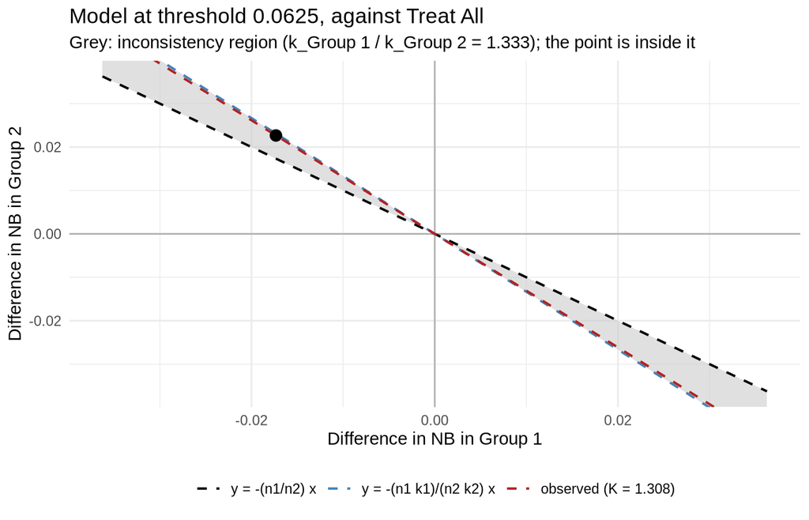

```r
plot(res_m, type = "region", threshold = 0.0625, k = c(`Group 1` = 60, `Group 2` = 45))
```

# 4 The case study of the paper: SCORE2, from published results

The paper took the net benefit of SCORE2 at a 3% threshold in men and women from a published validation study, assuming equal proportions of men and women: the difference in net benefit against treat all ($\Delta NB_i$, our `diff_NB`) was $-0.00160$ in men and $0.00345$ in women. Without patient data, `k_value()` does the calculation from these two values (its first argument, `diff_nb`); the relative risk reductions of LDL-lowering therapy (0.28 in men, 0.15 in women) give the ratio of $k$:

```r
k_value(c(Men = -0.0016, Women = 0.00345))
```

```
#> Subgroup difference in net benefit (diff_NB): Men -0.00160, Women 0.00345 (opposite signs)
#> Shares: Men 50%, Women 50%
#> K-value (k_Men / k_Women): 2.156
#> Population NB and population utility favour different strategies if k_Men / k_Women is beyond 2.156 (above it when k_Men > k_Women, below it when k_Men < k_Women).
```

```r
k_value(c(Men = -0.0016, Women = 0.00345), k = c(Men = 0.28, Women = 0.15))
```

```
#> Subgroup difference in net benefit (diff_NB): Men -0.00160, Women 0.00345 (opposite signs)
#> Shares: Men 50%, Women 50%
#> K-value (k_Men / k_Women): 2.156
#> Population NB and population utility favour different strategies if k_Men / k_Women is beyond 2.156 (above it when k_Men > k_Women, below it when k_Men < k_Women).
#> With k: k_Men / k_Women = 1.867, so population NB and population utility favour the same strategy.
```

```r
k_value(c(Men = -0.0016, Women = 0.00345), k = c(Men = 0.28, Women = 0.12))
```

```
#> Subgroup difference in net benefit (diff_NB): Men -0.00160, Women 0.00345 (opposite signs)
#> Shares: Men 50%, Women 50%
#> K-value (k_Men / k_Women): 2.156
#> Population NB and population utility favour different strategies if k_Men / k_Women is beyond 2.156 (above it when k_Men > k_Women, below it when k_Men < k_Women).
#> With k: k_Men / k_Women = 2.333, so population NB and population utility favour different strategies.
```

As in the paper: K = 2.156; the evidence-based ratio 1.867 is below it (the same strategy is favoured), and the hypothetical ratio 2.333 (a relative risk reduction of 0.12 in women) is above it.

# 5 Application: GUSTO-I by age group

We fit a logistic model for 30-day mortality on a random development sample of 5,000 patients of the GUSTO-I trial and validate it on 5,000 other patients, with two subgroups: patients younger than 65 years, and those 65 and over.

```r
set.seed(2023)
i <- sample(nrow(gusto))
dev <- gusto[i[1:5000], ]
val <- gusto[i[5001:10000], ]
fit <- glm(day30 ~ age + Killip + sysbp + pulse + pmi + miloc + sex,
           family = binomial, data = dev)
val$p_full <- predict(fit, newdata = val, type = "response")
val$age_group <- factor(val$age >= 65, labels = c("under 65", "65 and over"))
res_g <- nb_val(data = val,
                predicted_risk = "p_full",
                outcome = "day30",
                thresholds = seq(0.01, 0.30, by = 0.01),
                label = "Full",
                subgroup = "age_group")
res_g
```

```
#> Net benefit of Full: binary, n = 5000, 339 events (6.8%), prior improper Beta(0, 0)
#>
#>  threshold model NB_model   NB_all NB_none delta_NB
#>       0.01  Full  0.05852  0.05838       0  0.00013
#>       0.02  Full  0.05234  0.04878       0  0.00356
#>       0.03  Full  0.04653  0.03897       0  0.00756
#>       0.04  Full  0.04153  0.02896       0  0.01258
#>       0.05  Full  0.03716  0.01874       0  0.01842
#>       0.06  Full  0.03360  0.00830       0  0.02531
#>       0.07  Full  0.02939 -0.00237       0  0.02939
#>       0.08  Full  0.02817 -0.01326       0  0.02817
#>       0.09  Full  0.02652 -0.02440       0  0.02652
#>       0.10  Full  0.02478 -0.03578       0  0.02478
#> # 20 more thresholds; use summary() or as.data.frame()
#> # Subgroups (age_group): under 65, 65 and over; summary() checks them
```

**Step 1 and 2.** `summary()` gives the subgroup differences in net benefit against treat all (`diff_NB_under 65`, `diff_NB_65 and over`), their share-weighted sum (`diff_NB_population`), and whether they have the same sign; `plot(type = "subgroups")` draws them:

```r
summary(res_g, thresholds = c(0.02, 0.03, 0.04, 0.05, 0.06, 0.10))
```

```
#> Net benefit of Full: binary, n = 5000, 339 events (6.8%), prior improper Beta(0, 0)
#> Best strategy: Full 0.01-0.30
#> Largest delta_NB: Full 0.02939 at 0.07
#>
#>  threshold model    Se    Sp NB_model   NB_all NB_none delta_NB
#>       0.02  Full 0.962 0.324  0.05234  0.04878       0  0.00356
#>       0.03  Full 0.914 0.463  0.04653  0.03897       0  0.00756
#>       0.04  Full 0.858 0.571  0.04153  0.02896       0  0.01258
#>       0.05  Full 0.805 0.644  0.03716  0.01874       0  0.01842
#>       0.06  Full 0.749 0.711  0.03360  0.00830       0  0.02531
#>       0.10  Full 0.602 0.845  0.02478 -0.03578       0  0.02478
#>
#> Subgroups (age_group): under 65 (61%), 65 and over (39%); difference in net benefit (diff_NB) against Treat All
#> opposite signs at 0.03-0.06
#> K-value (k_under 65 / k_65 and over): 0.002349 to 0.03899
#>
#>  threshold model diff_NB_under 65 diff_NB_65 and over diff_NB_population
#>       0.02  Full          0.00568             0.00026            0.00356
#>       0.03  Full          0.01249            -0.00013            0.00756
#>       0.04  Full          0.02108            -0.00070            0.01258
#>       0.05  Full          0.03144            -0.00191            0.01842
#>       0.06  Full          0.04161            -0.00015            0.02531
#>       0.10  Full          0.08501             0.02237            0.06056
#>     signs       K
#>      same      NA
#>  opposite 0.00677
#>  opposite 0.02140
#>  opposite 0.03899
#>  opposite 0.00235
#>      same      NA
```

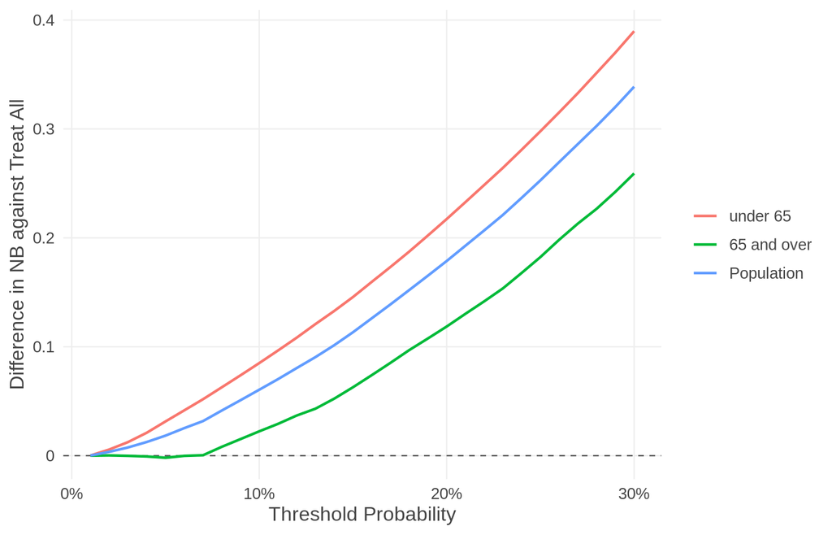

```r
plot(res_g, type = "subgroups")
```

At 3% to 6%, the model is better than treat all in one age group and worse in the other: the signs are opposite, so Step 3 is needed there. At the other thresholds the signs agree, and differences in $a - c$ between the age groups cannot change the conclusion.

**Step 3.** The K-values at these thresholds say how different $k$ would have to be between the age groups for population net benefit and utility to disagree. Here they range from 0.0023 to 0.039: the conclusion would change only if $k$ in patients 65 and over were 26 to 426 times that in younger patients, so the population conclusion is robust to plausible differences in $a - c$ between the age groups. If external evidence on the treatment effect by age is available, give it as `k`; the values below are hypothetical, for illustration only:

```r
summary(res_g, thresholds = opp$threshold,
        k = c(`under 65` = 0.30, `65 and over` = 0.20))
```

```
#> Net benefit of Full: binary, n = 5000, 339 events (6.8%), prior improper Beta(0, 0)
#> Best strategy: Full 0.01-0.30
#> Largest delta_NB: Full 0.02939 at 0.07
#>
#>  threshold model    Se    Sp NB_model  NB_all NB_none delta_NB
#>       0.03  Full 0.914 0.463  0.04653 0.03897       0  0.00756
#>       0.04  Full 0.858 0.571  0.04153 0.02896       0  0.01258
#>       0.05  Full 0.805 0.644  0.03716 0.01874       0  0.01842
#>       0.06  Full 0.749 0.711  0.03360 0.00830       0  0.02531
#>
#> Subgroups (age_group): under 65 (61%), 65 and over (39%); difference in net benefit (diff_NB) against Treat All
#> opposite signs at 0.03-0.06
#> K-value (k_under 65 / k_65 and over): 0.002349 to 0.03899
#> with k, population NB and population utility favour the same strategy at every threshold
#>
#>  threshold model diff_NB_under 65 diff_NB_65 and over diff_NB_population
#>       0.03  Full          0.01249           -0.000132            0.00756
#>       0.04  Full          0.02108           -0.000704            0.01258
#>       0.05  Full          0.03144           -0.001914            0.01842
#>       0.06  Full          0.04161           -0.000153            0.02531
#>     signs       K diff_utility consistent
#>  opposite 0.00677     0.002273       TRUE
#>  opposite 0.02140     0.003800       TRUE
#>  opposite 0.03899     0.005601       TRUE
#>  opposite 0.00235     0.007598       TRUE
```

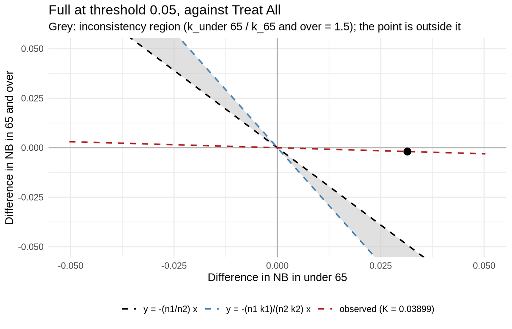

```r
plot(res_g, type = "region", threshold = z_opp,
     k = c(`under 65` = 0.30, `65 and over` = 0.20))
```

# 6 Options

**The comparator.** By default, the subgroup differences (`diff_NB`) are against treat all (as in the case study of the paper). `comparator` can be `"Treat None"`, `"best default"` (treat all or treat none, whichever is better in the whole sample at the threshold, the same for every subgroup) or another model:

```r
summary(res_g, thresholds = c(0.05, 0.2), comparator = "best default")
```

```
#> Net benefit of Full: binary, n = 5000, 339 events (6.8%), prior improper Beta(0, 0)
#> Best strategy: Full 0.01-0.30
#> Largest delta_NB: Full 0.02939 at 0.07
#>
#>  threshold model    Se    Sp NB_model  NB_all NB_none delta_NB
#>       0.05  Full 0.805 0.644  0.03716  0.0187       0  0.01842
#>       0.20  Full 0.345 0.958  0.01350 -0.1653       0  0.01350
#>
#> Subgroups (age_group): under 65 (61%), 65 and over (39%); difference in net benefit (diff_NB) against best default
#> opposite signs at 0.03-0.06
#> K-value (k_under 65 / k_65 and over): 0.002349 to 0.03899
#>
#>  threshold model diff_NB_under 65 diff_NB_65 and over diff_NB_population
#>       0.05  Full          0.03144            -0.00191            0.01842
#>       0.20  Full          0.00172             0.03189            0.01350
#>     signs       K
#>  opposite 0.03899
#>      same      NA
```

**Subgroup sizes.** By default the shares of the subgroups in the validation sample. If the target population differs (the paper assumed equal proportions of men and women for SCORE2), give `shares`:

```r
summary(res_g, thresholds = opp$threshold,
        shares = c(`under 65` = 0.5, `65 and over` = 0.5))
```

```
#> Net benefit of Full: binary, n = 5000, 339 events (6.8%), prior improper Beta(0, 0)
#> Best strategy: Full 0.01-0.30
#> Largest delta_NB: Full 0.02939 at 0.07
#>
#>  threshold model    Se    Sp NB_model  NB_all NB_none delta_NB
#>       0.03  Full 0.914 0.463  0.04653 0.03897       0  0.00756
#>       0.04  Full 0.858 0.571  0.04153 0.02896       0  0.01258
#>       0.05  Full 0.805 0.644  0.03716 0.01874       0  0.01842
#>       0.06  Full 0.749 0.711  0.03360 0.00830       0  0.02531
#>
#> Subgroups (age_group): under 65 (50%), 65 and over (50%); difference in net benefit (diff_NB) against Treat All
#> opposite signs at 0.03-0.06
#> K-value (k_under 65 / k_65 and over): 0.003667 to 0.06088
#>
#>  threshold model diff_NB_under 65 diff_NB_65 and over diff_NB_population
#>       0.03  Full          0.01249           -0.000132            0.00618
#>       0.04  Full          0.02108           -0.000704            0.01019
#>       0.05  Full          0.03144           -0.001914            0.01476
#>       0.06  Full          0.04161           -0.000153            0.02073
#>     signs       K
#>  opposite 0.01057
#>  opposite 0.03342
#>  opposite 0.06088
#>  opposite 0.00367
```

**More than two subgroups.** Step 2 is the same. There is no K-value (the paper notes that it does not generalise to a single ratio); instead, give plausible values or ranges of the $k_i$, and `summary()` checks whether the utility-weighted sum changes sign relative to the size-weighted sum (`diff_utility_lower`, `diff_utility_upper` and `consistent` with ranges):

```r
res_l <- nb_val(data = val,
                predicted_risk = "p_full",
                outcome = "day30",
                thresholds = seq(0.01, 0.30, by = 0.01),
                label = "Full",
                subgroup = "miloc")
summary(res_l, thresholds = c(0.01, 0.02, 0.05),
        k = list(Inferior = c(0.2, 0.3), Anterior = c(0.2, 0.3), Other = c(0.1, 0.3)))
```

```
#> Net benefit of Full: binary, n = 5000, 339 events (6.8%), prior improper Beta(0, 0)
#> Best strategy: Full 0.01-0.30
#> Largest delta_NB: Full 0.02939 at 0.07
#>
#>  threshold model    Se    Sp NB_model  NB_all NB_none delta_NB
#>       0.01  Full 0.982 0.141  0.05852 0.05838       0  0.00013
#>       0.02  Full 0.962 0.324  0.05234 0.04878       0  0.00356
#>       0.05  Full 0.805 0.644  0.03716 0.01874       0  0.01842
#>
#> Subgroups (miloc): Inferior (58%), Other (4%), Anterior (39%); difference in net benefit (diff_NB) against Treat All
#> opposite signs at 0.01
#> with k, population NB and population utility favour the same strategy at every threshold
#>
#>  threshold model diff_NB_Inferior diff_NB_Other diff_NB_Anterior
#>       0.01  Full          0.00037       0.00202         -0.00039
#>       0.02  Full          0.00470       0.00233          0.00199
#>       0.05  Full          0.01922       0.01654          0.01741
#>  diff_NB_population    signs diff_utility_lower diff_utility_upper consistent
#>             0.00013 opposite           0.000004           0.000055       TRUE
#>             0.00356     same           0.000704           0.001069       TRUE
#>             0.01842     same           0.003626           0.005526       TRUE
```

**Giving the subgroups.** `subgroup` takes a column name, several column names (their combinations, e.g. `subgroup = c("sex", "age_group")`), or a factor or vector with one subgroup per patient (e.g. `subgroup = val$age >= 65`). Every patient needs a subgroup, and numeric variables with many values must be cut into categories first. `as.data.frame()` has the net benefit of the whole sample (`"All"`) and of each subgroup, with the usual columns of `nb_val()`: its `delta_NB` is against the best default strategy of each group, not the comparator of the checks (for those, see `diff_NB` in `summary()`):

```r
head(as.data.frame(res_g), 3)
```

```
#>   threshold model subgroup    n   NB_model     NB_all NB_none     delta_NB
#> 1      0.01  Full      All 5000 0.05851515 0.05838384       0 0.0001313131
#> 2      0.02  Full      All 5000 0.05233878 0.04877551       0 0.0035632653
#> 3      0.03  Full      All 5000 0.04652990 0.03896907       0 0.0075608247
```

**Survival and competing-risk outcomes.** The net benefit of each subgroup uses the same estimator as `nb_val()` (Kaplan-Meier, or cIPCW with the censoring weights of the whole sample). For these estimators, the population net benefit is not exactly the size-weighted sum of the subgroup net benefits, which the framework assumes; the checks use the size-weighted sum.

**Not available with subgroups.** Credible intervals (`interval`), and combining results with `c()`: give all the models to one call of `nb_val()`.

# 7 Reference

Wang J, Wang KZ, Van Calster B, van Geloven N, Steyerberg E, Wynants L. Population-level decision curve analysis may mislead the evaluation of prediction model usefulness under subgroup utility heterogeneity.